# Casos Falsos Perfiles en Instagram

# Creación del modelo

# Lo primero que se debe tener en cuenta es que este es un modelo de clasificación

# El objetivo es crear un modelo para predecir más adelante si una cuenta puede ser o no falsa.

# En este ejemplo usaremos uno conocido como random forest.

# La ventaja es que es un modelo robusto ya que usa diferentes "mini modelos" para encontrar el resultado .

# En el siguiente ejemplo se podrá observar como se clasifica una cuenta falsa de acuerdo a las variables.

```
[Text(581.25, 660.625, '#follows <= 94.0\ngini = 0.5\nsamples = 355\nvalue = [279, 297]\nclass = a'),
```

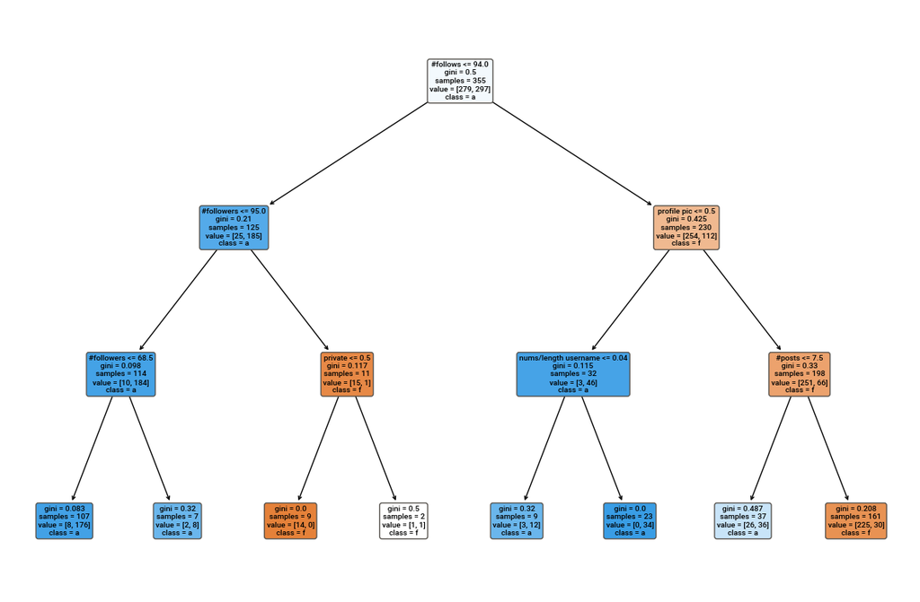

```python
from sklearn.ensemble import RandomForestClassifier
from sklearn.tree import  plot_tree
model = RandomForestClassifier(n_estimators=10, max_depth=3)

### split the data in train and test 67% and 33%
y=atrain["fake"]
## drop the quality column
x=atrain.drop(columns="fake")
# Train
model.fit(x, y)
# Extract single tree
estimator = model.estimators_[5]

fig = plt.figure(figsize=(15, 10))
plot_tree(model.estimators_[0],
          feature_names=['profile pic', 'nums/length username', 'fullname words',
       'nums/length fullname', 'name==username', 'description length',
       'external URL', 'private', '#posts', '#followers', '#follows'],
          class_names="fake",
          filled=True, impurity=True,
          rounded=True)
```

# Análisis del modelo

Este se análisis se realizará considerando el camino de si la cuenta es falsa.

# Como se puede observar en la caja superior, el modelo inicia diciendo que sin una cuenta sigue menos de 94 cuentas se puede considerar falsa.

# En el segundo nivel se observa en la caja azul que si la cuenta tiene menos de 95 seguidores, puede considerarse falsa.

# Finalmente, si después de descartar esas cuentas, se revisa y se observa que aun quedan algunas con menos de 68 seguidores estas se consideran falsas.

# Intenta hacer el mismo ejercicio combinando los demás resultados del árbol.

# Si no sabes cómo, puedes preguntarle a algún asesor para que te ayude a entender mejor el modelo.

# Si fueras el gerente de Instagram, ¿qué decisiones podrías tomar con esta información?.